# Finding Home in South Australia

A Data-Driven Rental Guide for International Students Coming to South Australia

Author

Md Soad Solaiman

Published

September 2, 2026

## The Letter That Started Everything

It arrived on a Tuesday morning, December 2024. I read it once, then again, then a third time to be sure. It says,

FROM · THE UNIVERSITY OF ADELAIDE · OFFICE OF ADMISSIONS

🎓

Congratulations, Soad.

We are delighted to inform you that your application for the Master of Data Science program has been accepted. … … …

Warm regards,  
The Admissions Office

The next few hours were a blur of phone calls and celebration. But by the next morning, a quieter, more practical question comes to my mind. One that every international student eventually faces.

**Where am I going to live?**

I opened a real estate website. The numbers just confused me. Which suburb? What’s a flat versus a house? Is $580 a week normal? Am I being ripped off? Is there something cheaper? Can I even afford this on a student income?

This is not just my story. It is the story of every international student who arrives in Adelaide holding an acceptance letter and a suitcase, with no real sense of the rental landscape they are about to enter.

So I am intending to do what any data science student should do. I found the data — six years of South Australian rental records from the SA Government Data Directory and I built this guide for the future students..A rental story of SA.

**TipAbout this guide**

All rent figures are **median weekly rent in AUD**. A student income of **$800/week** is assumed throughout, based on the 24-hour/week work limit under a student visa at approximately **$35/hour** after tax for standrd analysis. Also an interactive affordability calculator is available in chapter 10.

## Chapter 1 — Yes, It Is Going Up. Every Year.

Before asking *where* or *what type*, a student needs to understand the market’s basic direction. The answer is direct: Rents in South Australia is increasing every year..

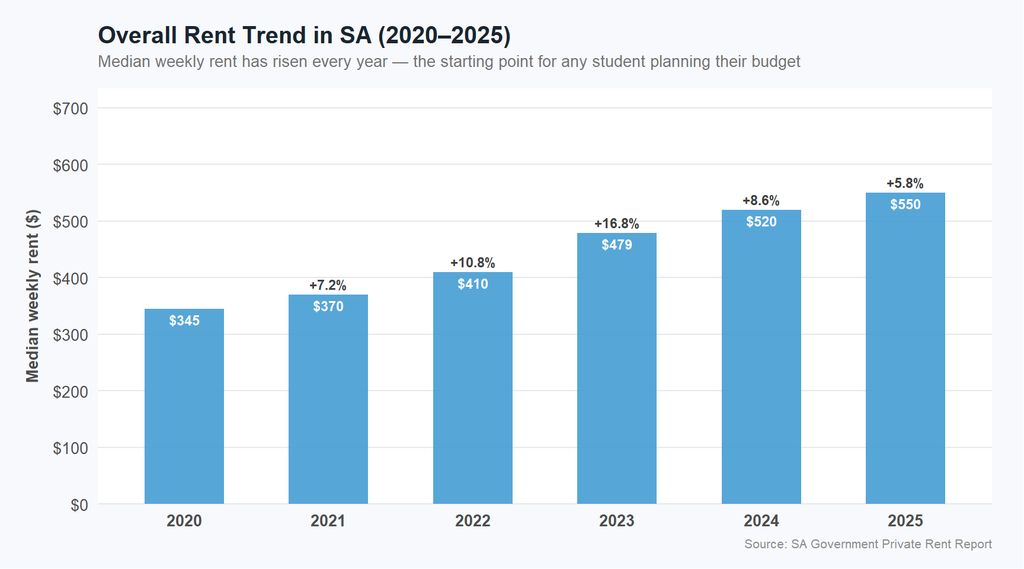

Figure 1: Median weekly rent across all of South Australia. Labels show the year-on-year growth rate. Source: SA Government Private Rent Report.

For many years, Adelaide was known as one of Australia’s more affordable cities for students. Finding a place to rent was rarely the biggest concern when planning to move. That changed during the COVID period.

Borders were closed. Universities went online. International students stopped arriving almost overnight. For a brief moment, the rental market exhaled. Demand dropped. Landlords held their prices. In 2020, the SA-wide median weekly rent was **$345**.

Unforetunately, tt did not last long.

When Australia reopened its borders in late 2021, the demand that had been building for nearly two years hit the market all at once. Students, migrants, and returning people flooded back simultaneously. There simply were not enough properties to absorb them. By 2023, rents had surged by nearly **17%** in a single year.

But there is some comfort in what has happened since. Growth has been slowing from that peak of nearly 17% down to around **9%** in 2024, and closer to **6%** by 2025. The market is moderating. The fever has broken, somewhat. But rents are still going up. Just less violently than before.

## Chapter 2 — Metro vs The Rest of SA

When you land in Adelaide for the first time, the city feels just awesome. It is compact, walkable, and amazingly easy to navigate. But the rental market is not like that. It is two very different worlds, and which world a student enters will shape their entire financial experience for a sudden period of time.

The first world is **Metro Adelaide** — the greater city, the suburbs, the university campuses, the coffee shops and the train lines. The second is the **Rest of State** — regional towns, coastal communities, farming country and wide open space. But for students it genuinely depends on the location of the campus.

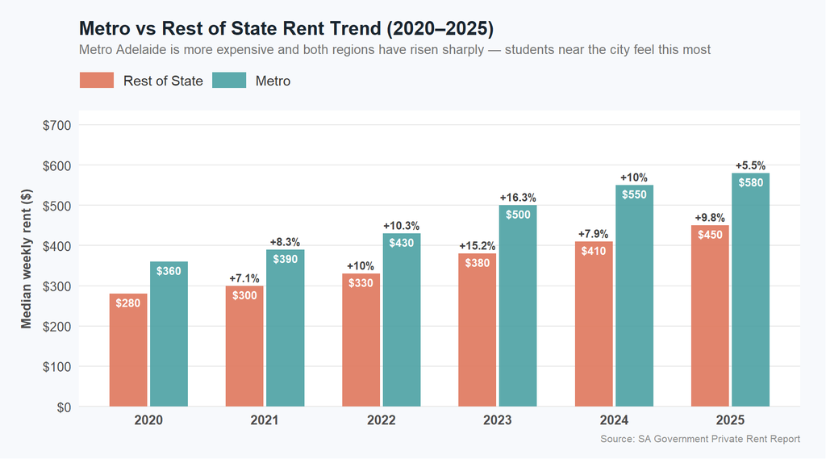

Both markets moved together through the post-COVID years, rising steadily through 2021 and 2022. Then 2023 arrived. Metro rents surged to **$500**, a **+16.3% jump** and Regional SA **+15.2% jump**. It means the shock hit everywhere at once.

The message is clear. Metro is expensive but stabilizing. Regional SA is cheaper but accelerating.

## Chapter 3 — The Burden That Compounds

Imagine arriving in Metro Adelaide in 2020 as a new student. A flat costs **$320 per week**. A house costs **$405**. Tight, but manageable. The lease is signed. Life begins.

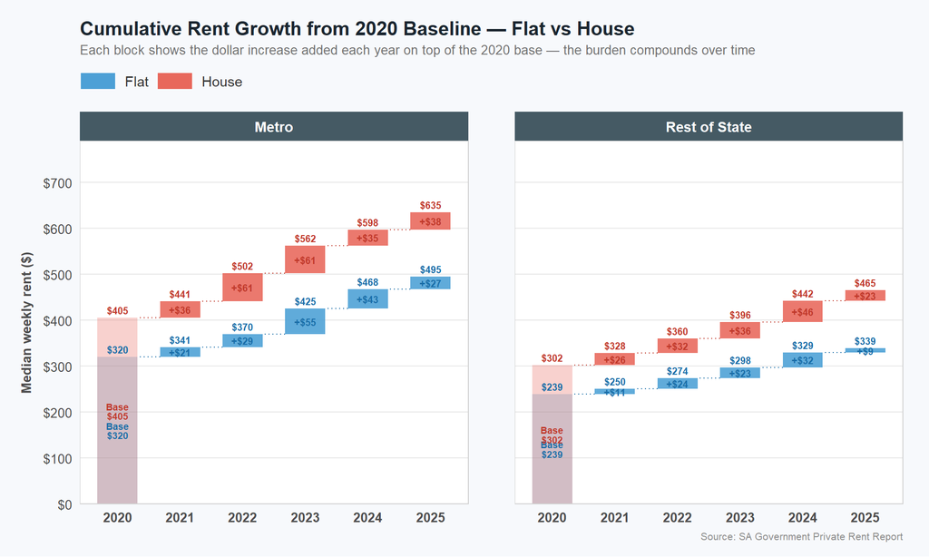

Figure 3: Each block shows the dollar increase added in that year, stacked on the 2020 base. The burden compounds. Source: SA Government Private Rent Report.

Without any warning, the flat that cost **$320** in 2020 now demands **$55 more** in a single renewal. Houses jump by **$61** in the same year. For a student already stretched thin — balancing study, part-time work, and the general cost of living in a foreign country, this is just unbearable.

This is what the chart is really showing. Not just growth, but accumulation. Every year’s increase does not replace the last one. It sits on top of it. The 2021 increase is still there in 2025. So is 2022. So is the shock of 2023. They do not disappear. They compound. And every student who arrives in Adelaide inherits all of them.

**WarningThe Burden That Compounds**

A student arriving in 2022 starts from **$370** and now paying **$495** for a metro flat.

## Chapter 4 — Flat or House?

Every student arriving in Adelaide faces the same early question. The answer is straightforward, depends on rent.

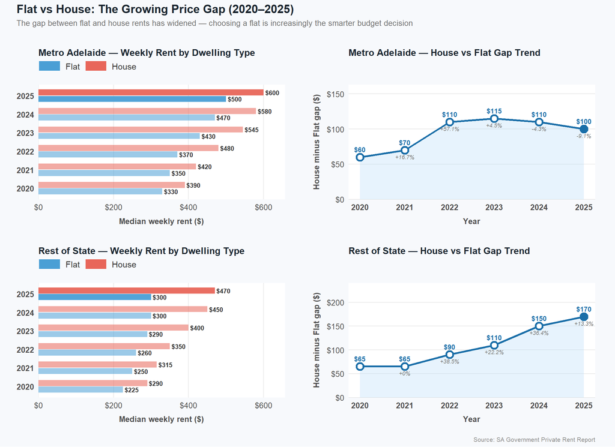

Figure 4: Left panels: flat and house rents by year. Right panels: the dollar gap between house and flat rents. The gap in regional SA has grown dramatically. Source: SA Government Private Rent Report.

In 2020, when the difference between renting a flat and a house was relatively small across South Australia. For many renters, the choice was still driven by lifestyle rather than cost.

As the years passed, houses began pulling away. In Metro Adelaide, the gap widened quickly, reaching its peak in2023. By 2025, the difference remained significant but **$100**. Fortunately, it has a decreasing trend.

## Chapter 5 — The Map of Metro Adelaide: Four Zones, Four Price Points

Once you know you will be renting in metro Adelaide, the next question is where. The Metro divides into four broad geographic rental zones — and they have meaningfully different price levels.

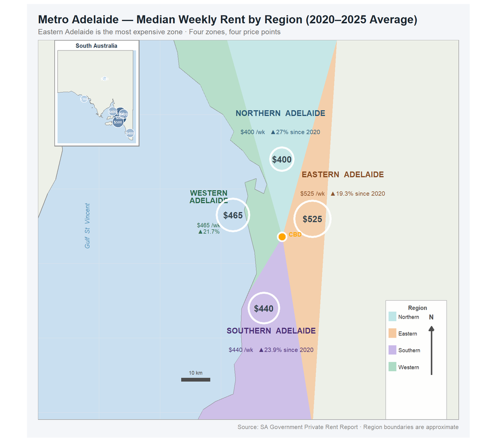

Figure 5: Metro Adelaide divided into four rental zones. Bubble size proportional to median rent (2020–2025). Growth since 2020 shown for each zone. Source: SA Government Private Rent Report. Region boundaries are approximate.

## Chapter 6 — The SA Region-wise Picture

Before we move to the affordability analysis, the boxplot below completes the picture. It shows the entire rent distribution across all regions and both dwelling types across all six years of data.

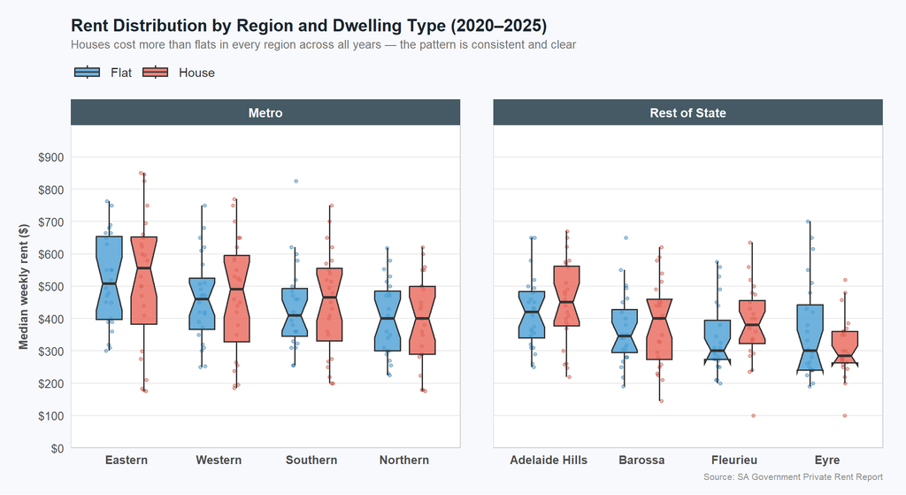

A notable observation: **Adelaide Hills** and **Barossa** in the Rest of State are priced comparably to, and sometimes, above Northern Metro. Their scenic character and proximity to Adelaide drive a lifestyle premium. Students considering regional SA for affordability reasons should check these regions carefully before assuming they are cheap.

## Chapter 7 — The 2025 Snapshot: What Does It Actually Cost?

All the previous chapters have told the story of how rents got to where they are today. This chart answers the practical question that follows: what does a property actually costs last year, depending on where it is and how many bedrooms it has?

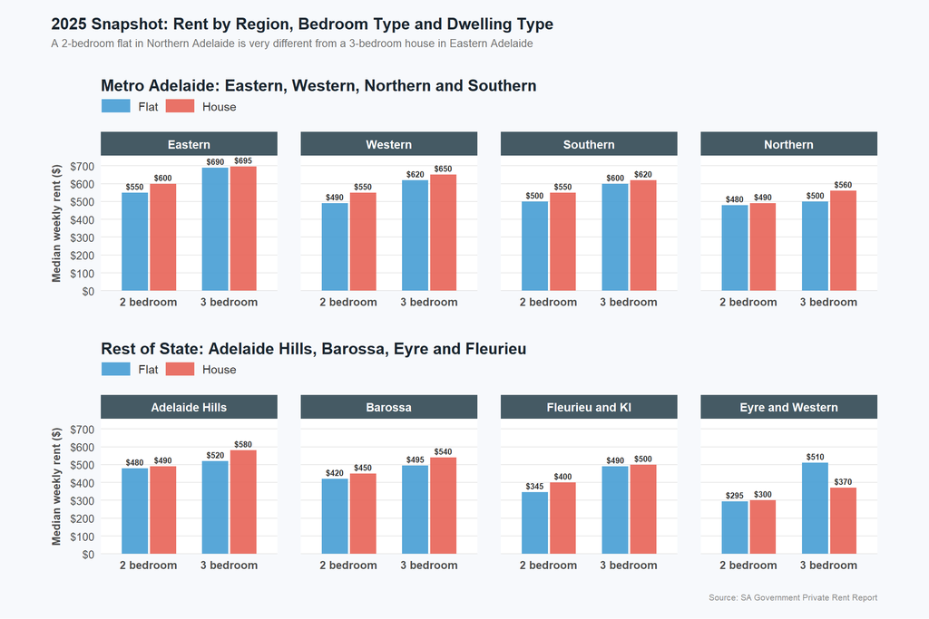

Figure 7: Exact 2025 median weekly rent by region, bedroom type and dwelling type. Flat in blue, House in red. Source: SA Government Private Rent Report.

Key comparisons a student should take from this chart:

Table 1: 2025 median weekly rent by region and dwelling type. Source: SA Government Private Rent Report.

| Region | 2BR Flat | 2BR House | 3BR Flat | 3BR House | Verdict |
| --- | --- | --- | --- | --- | --- |
| Eastern (Metro) | $550 | $600 | $690 | $695 | Premium |
| Western (Metro) | $490 | $550 | $620 | $650 | Expensive |
| Southern (Metro) | $500 | $550 | $600 | $620 | Mid-range |
| Northern (Metro) | $480 | $490 | $500 | $560 | Best value |
| Adelaide Hills | $480 | $490 | $520 | $580 | Scenic premium |
| Barossa | $420 | $450 | $495 | $540 | Regional mid |
| Eyre & Western | $295 | $300 | $510 | $370 | Cheapest SA |

## Chapter 8 — The Real Question: Can It Be Afforded on $800 a Week?

All the previous chapters have described the market. This one measures it against a student’s actual income. A student on a visa working the maximum allowed hours, 24 per week at approximately $35 per hour, earns around **$800 per week**. That is the budget. Now comes the hard part.

Housing experts define **stress** as spending more than **30% of income on rent**. Beyond **50%** is considered **severe**. Both lines are marked on the chart.

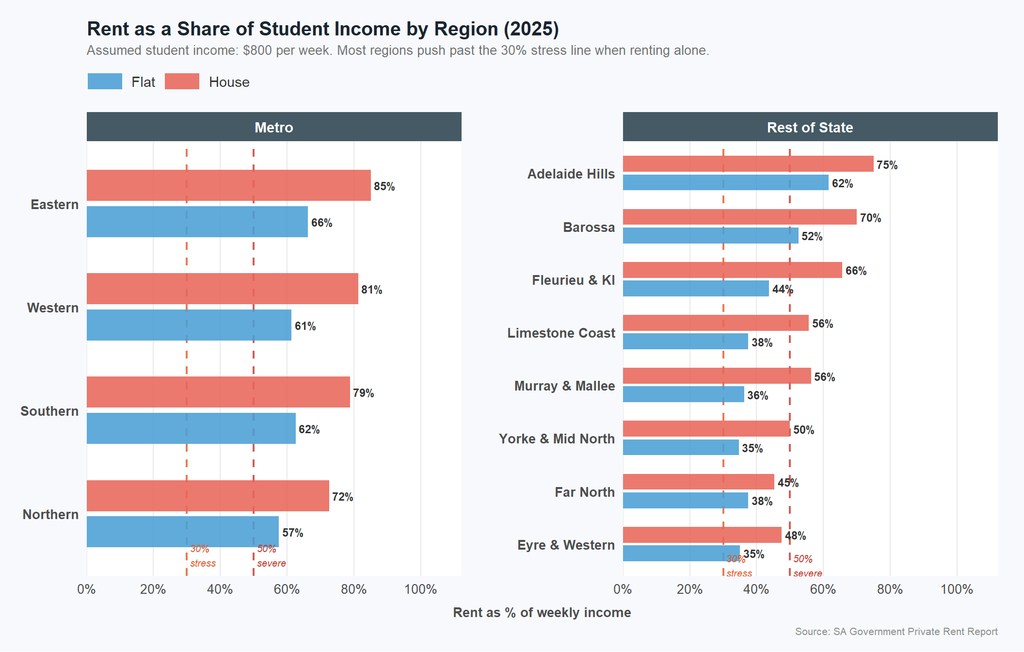

Figure 8: Rent as a percentage of weekly student income ($800) across all SA regions in 2025. The 30% stress and 50% severe stress thresholds are shown. Source: SA Government Private Rent Report.

**WarningRenting alone is not viable**

On $800 per week, renting alone any type of house or flat renting alone isn’t viable.

## Chapter 9 — The Solution: Sharing

The previous chapter ended with an uncomfortable situation. Renting alone does not work on a student income. But the data does not leave things there. It also shows exactly what does work.

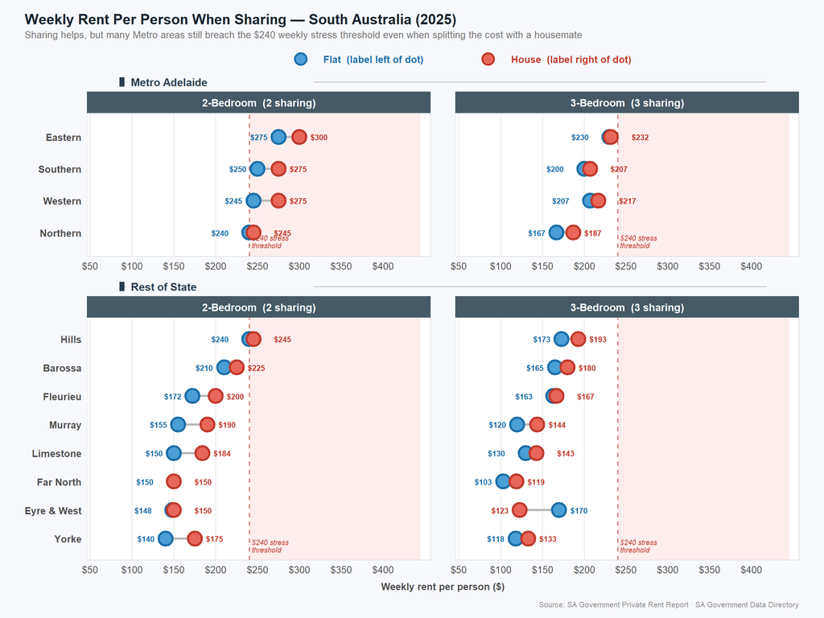

Figure 9: Weekly rent per person when sharing (2-bedroom = 2 sharing, 3-bedroom = 3 sharing). Red shaded zone indicates above the $240 stress threshold. Source: SA Government Private Rent Report.

The dashed line marks **$240 per week** — the 30% stress threshold. Everything to its left is affordable. Sharing changes that.

Two students splitting a 2-bedroom flat in Northern Adelaide each pay **$240** — right on the line. Three students sharing a 3-bedroom flat in the same zone each pay just **$167**. That is 21% of income. Comfortable. Manageable.The same picture is for the other zones of SA as well.

The situation is like the Adelaide rental market in 2025 is not built for single student incomes. Two or three students splitting a property transforms an unaffordable market into a workable one in almost every region, at almost every price point.

## Chapter 10 — Interactivity: What If the Income Is Different?

Throughout this guide, a student income of **$800 per week** has been the assumed baseline. But not every student arrives in the same financial situation.

A student whose spouse has full work rights brings a combined household income that changes the calculation entirely. That question cannot be answered by a static chart. It needs an interactive tool.

### Explore the Calculator

An interactive affordability calculator has been built to answer exactly these questions. It can be accessed here:

🔗 **[SA Rental Affordability Calculator](https://drsoso.shinyapps.io/my_shiny_app/)**

The calculator has three sections:

**Affordability Calculator** — Drag the income slider, filter dwelling type and select area group and watch every SA region update in real time.

**Sharing Calculator** — Select a bedroom size, drag the income slider, filter dwelling type and select area group and see what each person pays when the property is sharing.

**Rent Trend Explorer** — Select any SA region, drag the income slider, filter dwelling type and see how median rents for flats and houses have moved year by year.

## Conclusion — Welcome to Adelaide

**TipThe Data Verdict: Five Things to Know Before You Arrive**

1. **Rent has risen every year since 2020 — and will likely keep rising.** Budget for 6–10% annual increases.
2. **You cannot rent alone in Metro Adelaide on an $800/week student income or less without financial stress.** Every metro region exceeds the 30% threshold for solo renters.
3. **The strategy that works: Share a 3-bedroom flat or house with two other students.** This is the most cost-efficient structure in the entire dataset — bringing per-person costs down to $167–$232/week in metro.
4. **Northern Adelaide is the budget zone for metro living.** The most affordable rents in the city, a large student community, and a direct train line to the CBD.
5. **Choose a flat over a house wherever possible.** The flat-to-house price gap is high and growing — especially in regional SA.

Adelaide has a large, welcoming international student community. Its public transport network, unlike many Australian regional cities, makes it genuinely possible to live affordably.

To every student who just received their acceptance letter and opened a real estate app for the first time, this guide was written for you.Again, Welcome to Adelaide.

## References

Government of South Australia (2025). *Private Rent Report*. SA Government Data Directory. https://data.sa.gov.au/data/dataset/private-rent-report

Australian Bureau of Statistics (2025). *Total value of dwellings, December quarter 2024*. https://abs.gov.au/statistics/economy/price-indexes-and-inflation/total-value-dwellings/dec-quarter-2024

CoreLogic (2024). *Housing Market Trends Report*. https://www.corelogic.com.au

Australian Housing and Urban Research Institute (AHURI) (2023). *Understanding rental affordability in Australia*. https://www.ahuri.edu.au